# Testing Weibull Model

Stuart Lacy

26 April 2016

# 1 Introduction

The aim of this script is to better understand the Weibull parameterisation, and how survival probabilities are extracted from it directly using `pweibull`.

# 2 Setup

```r
library(dplyr)
library(abind)
library(rms)
library(survival)
library(devtools)
library(knitr)
opts_chunk$set(message=F, warning=F, error=T)
```

Let’s firstly build a survival model using this data.

```r
registry_data <- readRDS("../data/registry_data.rds")
mod <- survreg(Surv(stime, status) ~ sex + age, data=registry_data, dist='weibull')
mod
```

```
## Call:
## survreg(formula = Surv(stime, status) ~ sex + age, data = registry_data,
##     dist = "weibull")
##
## Coefficients:
## (Intercept)         sex         age
## 12.53799293 -2.47059192 -0.05435254
##
## Scale= 1.072893
##
## Loglik(model)= -9609.3   Loglik(intercept only)= -10327.8
##  Chisq= 1437.03 on 2 degrees of freedom, p= 0
## n=1784 (124 observations deleted due to missingness)
```

**NB: That what is called `scale` in the object is actually 1/shape**

```r
coefs <- mod$coefficients
scale <- mod$scale
```

# 3 Analysis

In the bootstrapping code, the survival probability is extracted using `pweibull` as follows:

In this example I’m going to predict the survival probability for a 60 year old man at 500 days.

```r
pred_st = 1 - pweibull(500, scale=exp(coefs[1] + 0 * coefs[2] + 60 * coefs[3]), shape=1/scale)
pred_st
```

```
## [1] 0.9440247
```

That’s a pretty high survival probability!

However there isn’t a method in survreg for calculating this so how is it done otherwise?! Since this is an AFT model rather than a PH it seems that it’s easier to predict the event time rather than survival probability.

**NB: When using predict, we’re predicting on the original scale (i.e. F(t), so ensure that I transform the output again)** Anyway this produces the same number of days as Simon’s method so that’s a relief.

```r
predict(mod, newdata=list(age=60, sex=0), type='quantile', p=1-pred_st)
```

```
##   1
## 500
```

# 4 Using `flexsurv`

```r
library(flexsurv)
```

Let’s try using the `flexsurv` package.

```r
modflex <- flexsurvreg(Surv(stime, status) ~ sex + age, data=registry_data, dist='weibull')
```

This should make the same model as before.

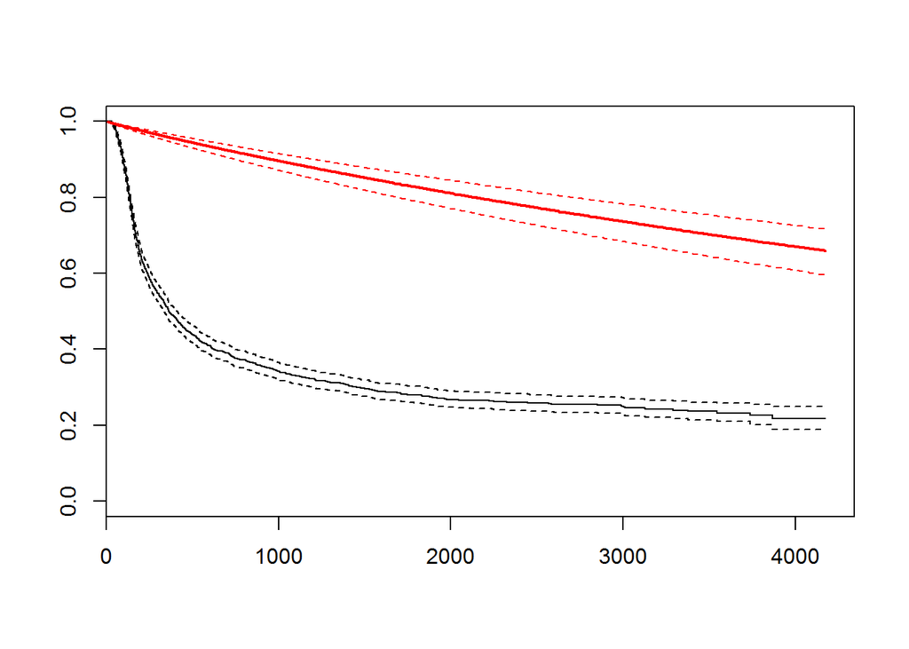

```r
plot(modflex, newdata=list(age=60, sex=0))
```

But instead the survival probability at 500 days appears to be far higher. The time with a survival probability of 0.70 looks to be around 3500.

`summary.flexsurvreg` provides a direct calculation of these probabilities.

We can find the survival probability at t=500, luckily this is exactly that returned by Simon’s manual method.

```r
summary(modflex, newdata=list(age=60, sex=0), t=500)
```

```
## sex=0, age=60
##   time       est       lcl       ucl
## 1  500 0.9440247 0.9305585 0.9554925
```

Likewise can find the time when probability is around 0.944.

```r
probs <- summary(modflex, newdata=list(age=60, sex=0))[[1]]
probs[probs$est < 0.9445 & probs$est > 0.9435, ]
```

```
##     time       est       lcl       ucl
## 373  497 0.9443289 0.9311871 0.9564743
## 374  499 0.9441261 0.9309365 0.9563132
## 375  501 0.9439234 0.9306861 0.9561521
## 376  504 0.9436195 0.9303107 0.9559105
```

Yep, this is around 500 days.

# 5 Questions

- Where is the maths that states how `pweibull` and S(t) are related, as a function of covariates?